# FA_exmaple

Seo eunyu

2021 11 14

# 0. 요인분석 패키지

```r
library(tidyverse)
library(psych)
```

```r
library(corrplot)
```

# 1. 자료 읽기

```r
DF<-read.csv('QUSTNAIR.csv')
dim(DF)
```

```
## [1] 130  18
```

# 2.자료 정리

```r
# 변수명 변경
DF<-rename(DF,
           '치수안맞음'=Q01, '컵작음'=Q02, '컵조임'=Q03,'겨드랑이조임'=Q04,
           '원단신축성없음'=Q05, '거친촉감'=Q06, '땀흡수안됨'=Q07, '답답함'=Q08,
           '앞중심들뜸'=Q09,'위로올라감'=Q10,'어깨끈흘러내림'=Q11, '뒤여밈불편'=Q12,
           '앞여밈불편'=Q13,'가슴못받침'=Q14, '가슴못모음'=Q15, '가슴못고정'=Q16,
           '디자인안세련'=Q17, '디자인안다양'=Q18)
head(DF)
```

```
##   치수안맞음 컵작음 컵조임 겨드랑이조임 원단신축성없음 거친촉감 땀흡수안됨
## 1          2      2      2            4              4        4          3
## 2          2      5      2            4              4        5          4
## 3          3      2      2            3              2        3          2
## 4          4      5      2            4              3        4          3
## 5          2      2      4            4              3        4          4
## 6          2      2      1            3              4        4          4
##   답답함 앞중심들뜸 위로올라감 어깨끈흘러내림 뒤여밈불편 앞여밈불편 가슴못받침
## 1      3          2          3              4          4          4          4
## 2      2          4          2              4          4          4          4
## 3      2          4          4              3          3          3          3
## 4      4          3          5              5          1         NA          4
## 5      2          4          2              4          4          4          4
## 6      3          3          2              4          2          2          1
##   가슴못모음 가슴못고정 디자인안세련 디자인안다양
## 1          3          4            2            1
## 2          4          4            5            1
## 3          3          3            3            3
## 4          2          4            4            3
## 5          4          4            3            4
## 6          3          3            4            4
```

```r
# 결측값 제거
X<-na.omit(DF)
dim(X) # 결측치 제거 후 데이터 101개, 변수는 18개 이다.
```

```
## [1] 101  18
```

```r
head(X,10)
```

```
##    치수안맞음 컵작음 컵조임 겨드랑이조임 원단신축성없음 거친촉감 땀흡수안됨
## 1           2      2      2            4              4        4          3
## 2           2      5      2            4              4        5          4
## 3           3      2      2            3              2        3          2
## 5           2      2      4            4              3        4          4
## 6           2      2      1            3              4        4          4
## 7           2      2      2            3              3        4          4
## 8           2      1      1            3              2        4          2
## 9           1      2      3            2              2        3          2
## 10          2      2      2            4              2        4          2
## 11          2      2      2            5              4        5          4
##    답답함 앞중심들뜸 위로올라감 어깨끈흘러내림 뒤여밈불편 앞여밈불편 가슴못받침
## 1       3          2          3              4          4          4          4
## 2       2          4          2              4          4          4          4
## 3       2          4          4              3          3          3          3
```

[output cut: 18 more lines]

# 3. 자료 탐색 / 요인분석 적절성

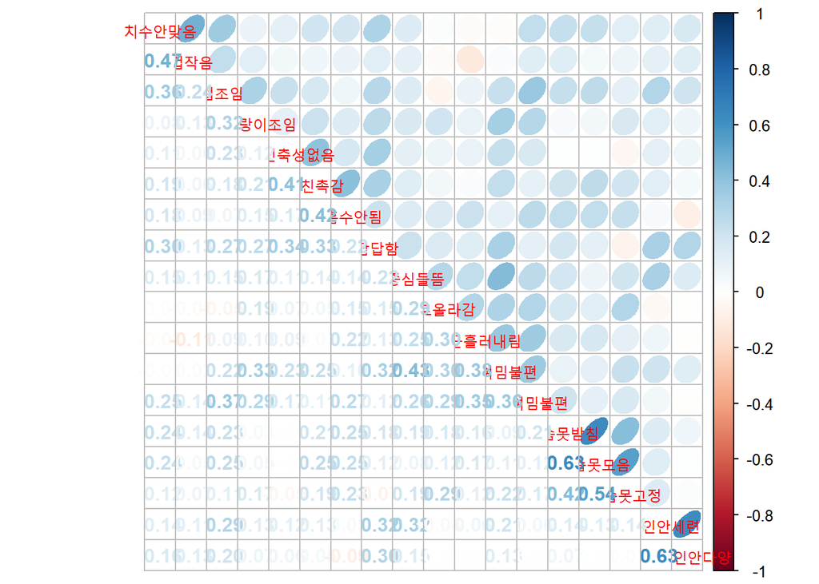

```r
# 상관행렬 시각화
R<-cor(X)
corrplot.mixed(R, upper='ellipse')
```

```r
# KMO
KMO(R)
```

```
## Kaiser-Meyer-Olkin factor adequacy
## Call: KMO(r = R)
## Overall MSA =  0.7
## MSA for each item =
##     치수안맞음         컵작음         컵조임   겨드랑이조임 원단신축성없음
##           0.65           0.65           0.76           0.75           0.72
##       거친촉감     땀흡수안됨         답답함     앞중심들뜸     위로올라감
##           0.71           0.71           0.69           0.75           0.69
## 어깨끈흘러내림     뒤여밈불편     앞여밈불편     가슴못받침     가슴못모음
##           0.73           0.72           0.72           0.74           0.67
##     가슴못고정   디자인안세련   디자인안다양
##           0.68           0.63           0.61
```

=> overall MSA가 0.7이고 각 변수별 MSA가 0.5 이하인 것이 없다. 따라서 요인분석 진행이 가능하다.

```r
# Bartlett 구형성검정
cortest.bartlett(R, n=nrow(X))
```

```
## $chisq
## [1] 477.3045
##
## $p.value
## [1] 5.076879e-35
##
## $df
## [1] 153
```

=> p-value가 0.05 이하이므로 Reject H0 (H0 : 변수들끼리 전혀 관계가 없다.) 한다. 따라서 요인분석 진행 가능하다.

# 4. 주성분 요인분석 1

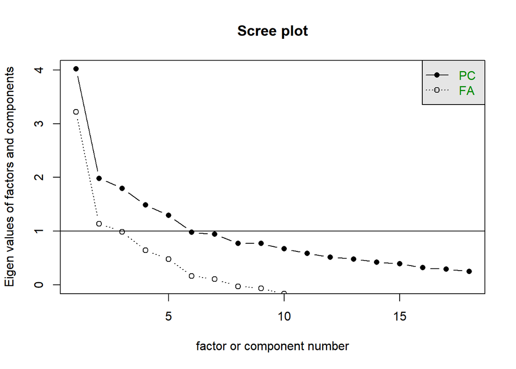

```r
# screeplot 으로 적절한 요인 수 결정하기
scree(R, hline=1)
```

=> 다소 애매하지만 주성분 개수는 5개로 지정함

```r
# 회전없이 주성분 요인분석
Mfapc<-principal(X, nfactors = 5, rotate='none')
print(Mfapc, digit=4)
```

```
## Principal Components Analysis
## Call: principal(r = X, nfactors = 5, rotate = "none")
## Standardized loadings (pattern matrix) based upon correlation matrix
##                   PC1     PC2     PC3     PC4     PC5     h2     u2   com
## 치수안맞음     0.4583  0.2763  0.4452 -0.2162  0.3427 0.6489 0.3511 4.001
## 컵작음         0.2943  0.3259  0.3618 -0.1613  0.4979 0.5976 0.4024 3.643
## 컵조임         0.5530  0.3057  0.1481 -0.0687  0.2719 0.4999 0.5001 2.309
## 겨드랑이조임   0.4564  0.0694 -0.2532 -0.1355  0.2056 0.3378 0.6622 2.299
## 원단신축성없음 0.3759  0.2330 -0.2490 -0.4773 -0.2934 0.5715 0.4285 3.795
## 거친촉감       0.5095  0.0244  0.0545 -0.4593 -0.4838 0.7081 0.2919 3.009
## 땀흡수안됨     0.4627 -0.2763  0.0834 -0.3979 -0.2055 0.4980 0.5020 3.156
## 답답함         0.5569  0.3819 -0.1473 -0.1566 -0.2351 0.5575 0.4425 2.556
## 앞중심들뜸     0.5235  0.0026 -0.2895  0.2787  0.0888 0.4434 0.5566 2.229
## 위로올라감     0.3818 -0.4171 -0.3319  0.1395  0.1207 0.4639 0.5361 3.350
## 어깨끈흘러내림 0.3944 -0.3556 -0.4043  0.1458  0.0569 0.4700 0.5300 3.278
## 뒤여밈불편     0.5806 -0.0645 -0.5173  0.1211  0.0094 0.6236 0.3764 2.097
## 앞여밈불편     0.5546 -0.1757 -0.2198 -0.1226  0.4776 0.6299 0.3701 2.643
## 가슴못받침     0.5382 -0.3165  0.4837  0.1736 -0.1039 0.6647 0.3353 2.951
## 가슴못모음     0.5101 -0.3837  0.5323  0.1525 -0.2057 0.7563 0.2437 3.326
## 가슴못고정     0.4707 -0.4650  0.3147  0.2779 -0.0636 0.6181 0.3819 3.423
## 디자인안세련   0.4464  0.5117  0.0187  0.4976 -0.2426 0.7680 0.2320 3.408
## 디자인안다양   0.2998  0.6048  0.0131  0.4937 -0.1712 0.7289 0.2711 2.628
##
##                          PC1    PC2    PC3    PC4    PC5
## SS loadings           4.0164 1.9848 1.7990 1.4876 1.2984
## Proportion Var        0.2231 0.1103 0.0999 0.0826 0.0721
## Cumulative Var        0.2231 0.3334 0.4333 0.5160 0.5881
## Proportion Explained  0.3794 0.1875 0.1699 0.1405 0.1226
## Cumulative Proportion 0.3794 0.5669 0.7368 0.8774 1.0000
##
## Mean item complexity =  3
## Test of the hypothesis that 5 components are sufficient.
##
## The root mean square of the residuals (RMSR) is  0.0732
##  with the empirical chi square  165.7622  with prob <  3.597e-09
##
## Fit based upon off diagonal values = 0.8839
```

=> 요인 5개로는 전체 분산의 58.8% 설명 가능하다. 50% 이상 설명 가능하므로 요인 개수는 5개로 한다.

```r
# 공통성, 특수성
data.frame('공통성'=Mfapc$communality, '특수성'= Mfapc$uniquenesses)
```

```
##                   공통성    특수성
## 치수안맞음     0.6488538 0.3511462
## 컵작음         0.5976495 0.4023505
## 컵조임         0.4998979 0.5001021
## 겨드랑이조임   0.3377943 0.6622057
## 원단신축성없음 0.5714675 0.4285325
## 거친촉감       0.7081332 0.2918668
## 땀흡수안됨     0.4979755 0.5020245
## 답답함         0.5575247 0.4424753
## 앞중심들뜸     0.4433895 0.5566105
## 위로올라감     0.4639151 0.5360849
## 어깨끈흘러내림 0.4699719 0.5300281
## 뒤여밈불편     0.6236277 0.3763723
## 앞여밈불편     0.6299203 0.3700797
## 가슴못받침     0.6646909 0.3353091
## 가슴못모음     0.7562745 0.2437255
## 가슴못고정     0.6181127 0.3818873
## 디자인안세련   0.7679798 0.2320202
## 디자인안다양   0.7289215 0.2710785
```

=> 공통성이 0.5 이상 경우에만 바람직한 변수이다. 따라서 컵조임, 겨드랑이조임, 땀흡수안됨, 압중심들뜸, 위로올라감, 어깨끈흘러내림은 바람직한 변수가 아닌 것으로 확인된다.

```r
# 초기고유값, 비율분산, 누적분석
data.frame('초기고유값'= Mfapc$values,
           '비율분산'=Mfapc$values/ sum(Mfapc$values)*100,
           '누적분산'= cumsum(Mfapc$values/ sum(Mfapc$values)*100))
```

```
##    초기고유값  비율분산  누적분산
## 1   4.0164205 22.313447  22.31345
## 2   1.9847681 11.026490  33.33994
## 3   1.7989658  9.994255  43.33419
## 4   1.4875795  8.264331  51.59852
## 5   1.2983664  7.213147  58.81167
## 6   0.9819655  5.455364  64.26703
## 7   0.9420398  5.233555  69.50059
## 8   0.7746346  4.303525  73.80411
## 9   0.7731717  4.295398  78.09951
## 10  0.6699534  3.721963  81.82147
## 11  0.5893456  3.274142  85.09562
## 12  0.5178818  2.877121  87.97274
## 13  0.4821021  2.678345  90.65108
## 14  0.4260390  2.366883  93.01797
## 15  0.3931125  2.183959  95.20192
## 16  0.3206782  1.781545  96.98347
## 17  0.2910174  1.616763  98.60023
## 18  0.2519581  1.399767 100.00000
```

```r
# 회전 전 요인행렬
fa.sort(Mfapc$loadings)
```

```
##
## Loadings:
##                PC1    PC2    PC3    PC4    PC5
## 뒤여밈불편      0.581        -0.517  0.121
## 답답함          0.557  0.382 -0.147 -0.157 -0.235
## 앞여밈불편      0.555 -0.176 -0.220 -0.123  0.478
## 컵조임          0.553  0.306  0.148         0.272
## 가슴못받침      0.538 -0.316  0.484  0.174 -0.104
## 앞중심들뜸      0.523        -0.289  0.279
## 거친촉감        0.509               -0.459 -0.484
## 가슴못고정      0.471 -0.465  0.315  0.278
## 땀흡수안됨      0.463 -0.276        -0.398 -0.205
## 치수안맞음      0.458  0.276  0.445 -0.216  0.343
## 겨드랑이조임    0.456        -0.253 -0.136  0.206
## 디자인안다양    0.300  0.605         0.494 -0.171
## 디자인안세련    0.446  0.512         0.498 -0.243
## 위로올라감      0.382 -0.417 -0.332  0.140  0.121
## 가슴못모음      0.510 -0.384  0.532  0.153 -0.206
## 어깨끈흘러내림  0.394 -0.356 -0.404  0.146
## 원단신축성없음  0.376  0.233 -0.249 -0.477 -0.293
## 컵작음          0.294  0.326  0.362 -0.161  0.498
##
##                  PC1   PC2   PC3   PC4   PC5
## SS loadings    4.016 1.985 1.799 1.488 1.298
## Proportion Var 0.223 0.110 0.100 0.083 0.072
## Cumulative Var 0.223 0.333 0.433 0.516 0.588
```

요인2: {답답함, 컵조임, 디자인안다양, 디자인안세련, 컵작음} - {가슴못받침, 가슴못고정, 위로올라감, 가슴못모음, 어깨끈흘러내림}

요인4: {디자인안다양, 디자인안세련}-{거친촉감, 땀흡수안됨, 원단신축성없음}

요인5: {앞여밈불편, 치수안맞음, 컵작음}-{거친촉감}

=> 요인별 분류 및 해석이 어렵고 겹치는 변수도 있음

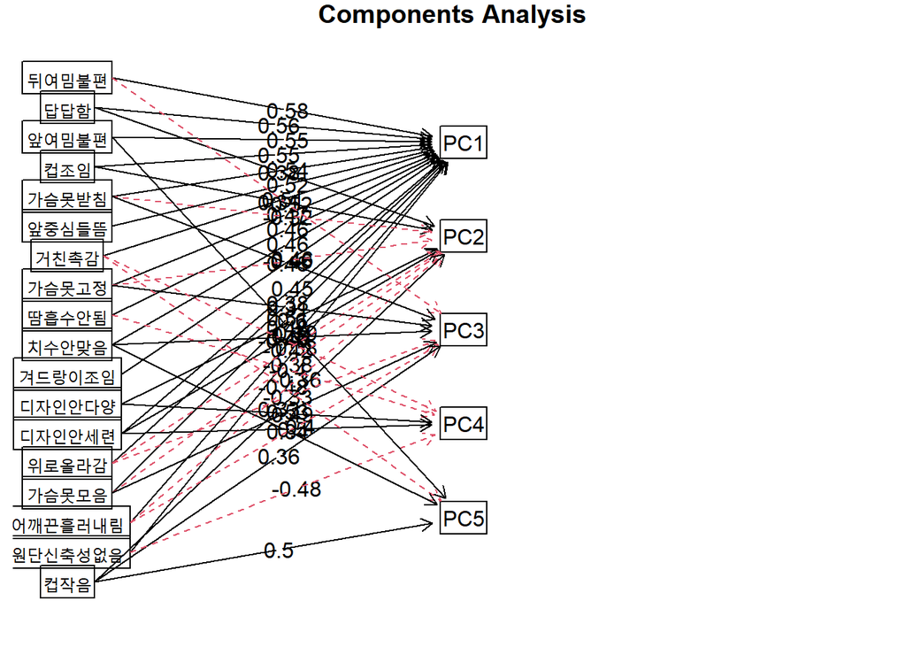

```r
# diagram
fa.diagram(Mfapc, simple = FALSE, cut=0.3, digits = 2)
```